# Estimated change in pneumonia in Latin American countries, subnational analyses

```
#>      var1
#> 0.8681324
```

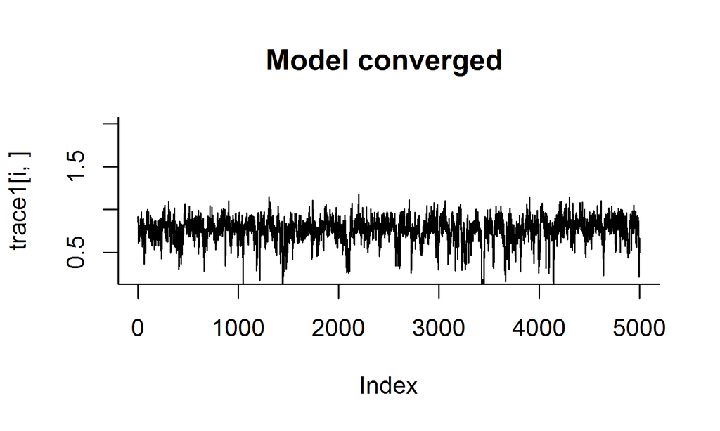

```
#>      var1
#> 0.8262804
```

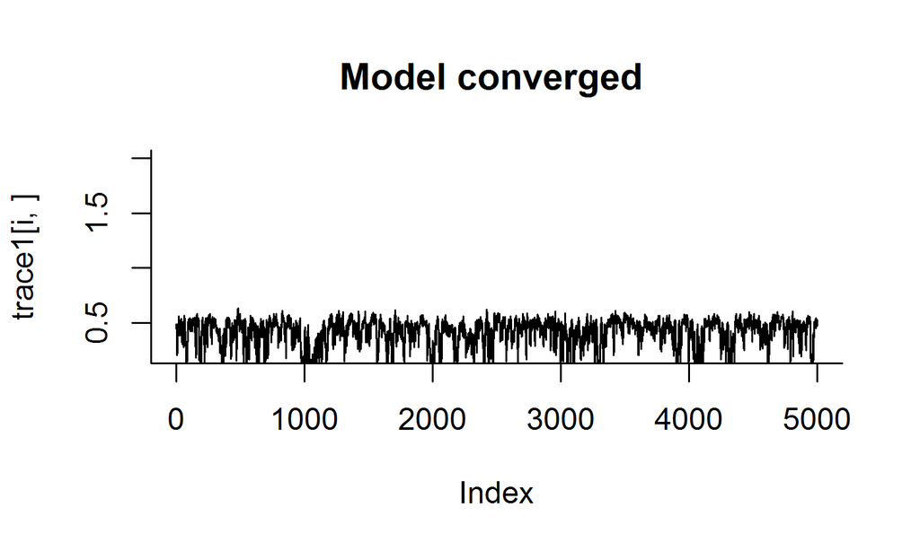

```
#>      var1
#> 0.6221341
```

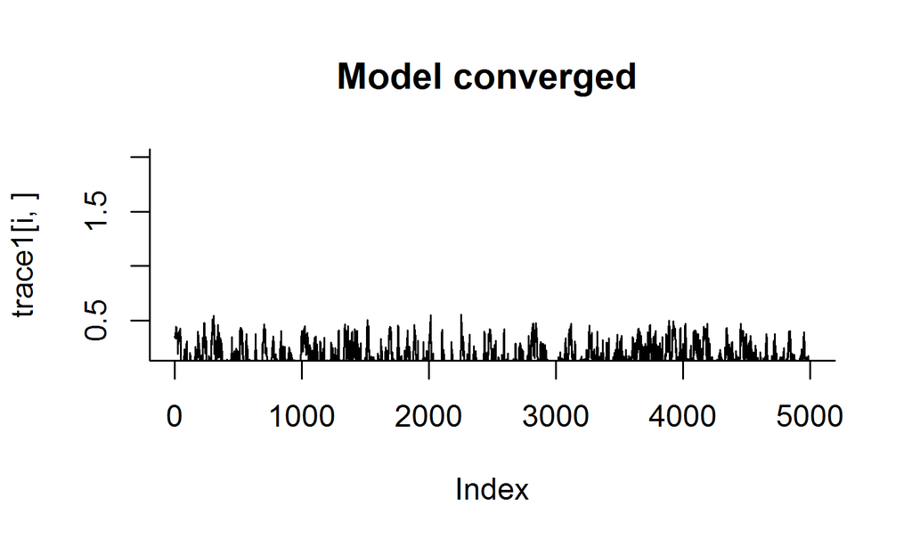

```
#>       var1
#> 0.08122547
```

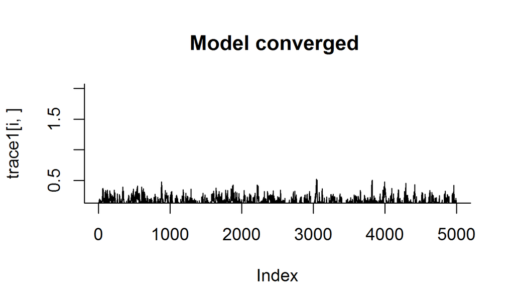

```
#>        var1
#> 0.001244866
```

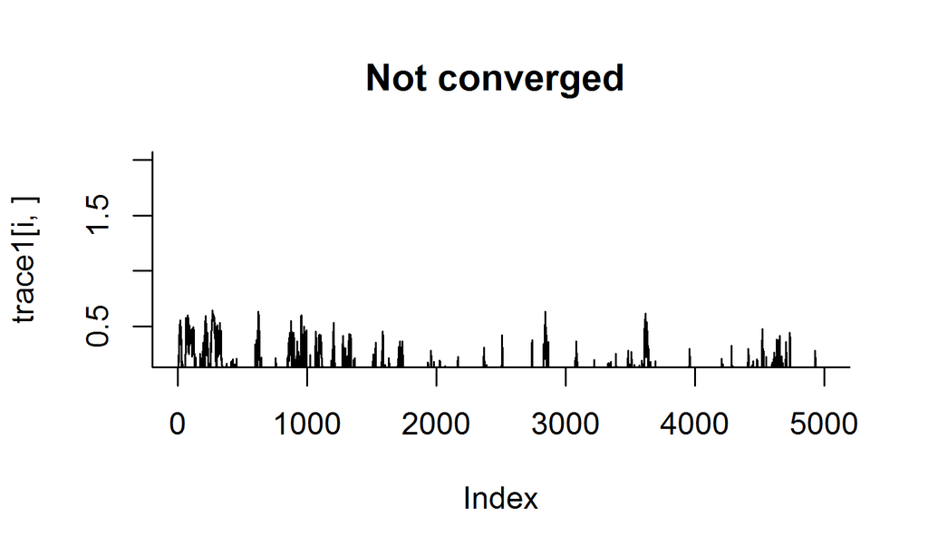

```
#>       var1
#> 0.06318118
```

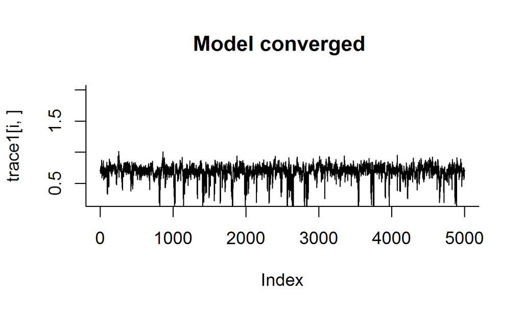

```
#>      var1
#> 0.4218451
```

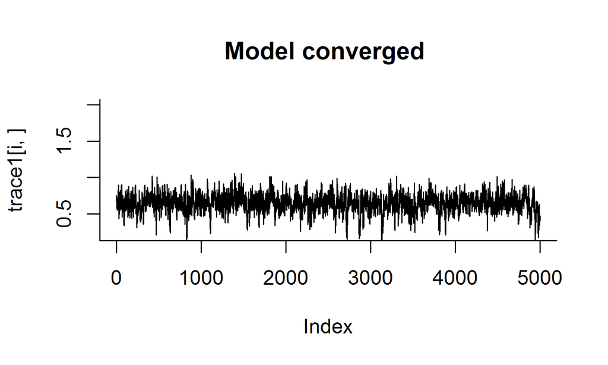

```
#>      var1
#> 0.1124064
```

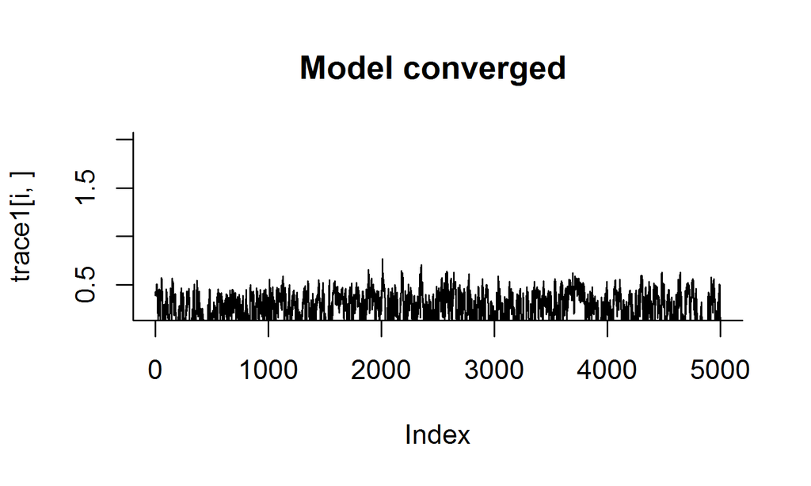

```
#>        var1
#> 0.004501331
```

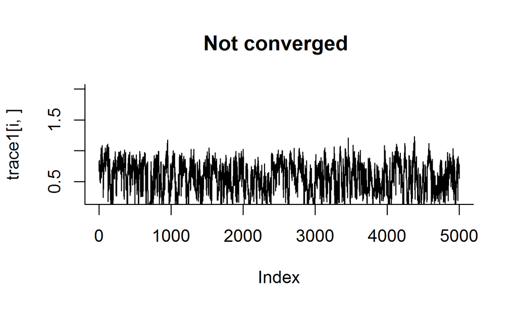

```
#>      var1
#> 0.1249733
```

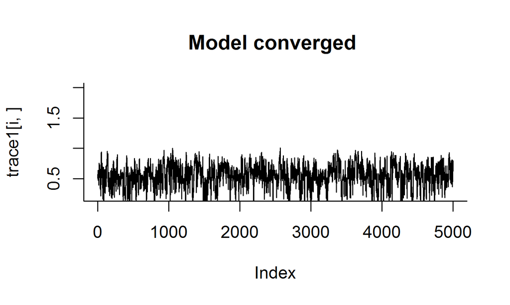

```
#>       var1
#> 0.01452017
```

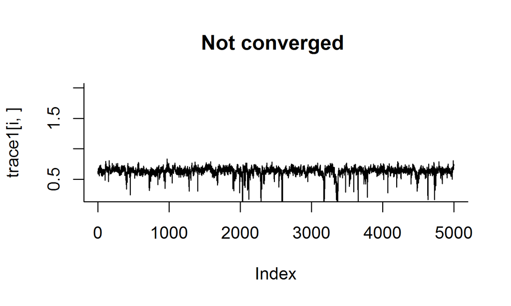

```
#>      var1
#> 0.3826492
```

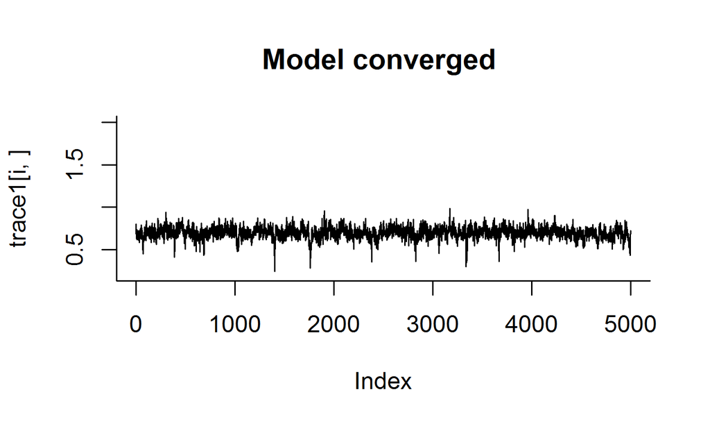

```
#>      var1
#> 0.2457908
```

[3 more figures not shown]

```r
n.iter<-ncol(impact_results$full$rr_iter)
thin=1
trace1<-impact_results$full$rr_iter[,seq(from=1, to=n.iter, by=thin)] #thin
for(i in 1: nrow(trace1)){
  geweke.p<- pnorm(abs(geweke.diag(mcmc(trace1[i,]))$z),lower.tail=FALSE)*2
  print(geweke.p)
if(geweke.p>0.05){con.stat<-'Model converged'
  }else{
    con.stat<-'Not converged'
  }
   plot(trace1[i,], type='l', main=paste0(con.stat,' ',colnames(trace1)[i]), bty='l', ylim=c(0.2,2))
}
```

# Results

## Compare estimates from different models

This shows the estimated rate ratio and 95% credible intervals from a synthetic controls analysis; a time-trend analysis where we used the specified denominator (all non-respiratory deaths) to adjust the number of pneumonia deaths in each month and a linear trend for time; a classic interrupted time series analysis (segmented regression); and the STL+PCA approach, which smooths and combines the control variables prior to including them in the model.

```r
results.table<- cbind.data.frame(
  #impact_results$best$rr_mean_intervals,
  impact_results$full$rr_mean_intervals,
  impact_results$time$rr_mean_intervals,
  #impact_results$time_no_offset$rr_mean_intervals,
  impact_results$its$rr_mean_intervals,
  impact_results$pca$rr_mean_intervals)

  table<-xtable(results.table)
  htmlTable(table)
```

|  | Synthetic controls Estimate (95% CI) | Time trend Estimate (95% CI) | Classic ITS (95% CI) | STL+PCA Estimate (95% CI) |
| --- | --- | --- | --- | --- |
| 92_1 | 0.78 (0.38, 0.98) | 1.56 (1.2, 2.1) | 1.49 (1.16, 1.92) | 1.11 (0.09, 2.34) |
| 92_10 | 0.45 (0.1, 0.57) | 0.82 (0.7, 0.98) | 0.8 (0.67, 0.96) | 3.61 (1.89, 5.77) |
| 92_11 | 0.12 (0.02, 0.41) | 0.59 (0.41, 0.84) | 0.52 (0.38, 0.72) | 0.42 (0.21, 0.56) |
| 92_12 | 0.13 (0.03, 0.33) | 1.52 (1.04, 2.31) | 0.98 (0.61, 1.54) | 0.11 (0.06, 0.18) |
| 92_13 | 0.02 (0, 0.45) | 1.22 (0.99, 1.52) | 1.2 (0.99, 1.46) | 1.94 (1.24, 2.74) |
| 92_14 | 0.71 (0.33, 0.85) | 0.83 (0.66, 1.03) | 0.69 (0.54, 0.87) | 1.3 (1.07, 1.55) |
| 92_15 | 0.64 (0.36, 0.87) | 1.03 (0.71, 1.5) | 1.02 (0.71, 1.47) | 1.46 (0.62, 2.45) |
| 92_2 | 0.27 (0.01, 0.53) | 1.27 (0.99, 1.61) | 1.17 (0.93, 1.47) | 6.71 (2.51, 15.18) |
| 92_3 | 0.59 (0.09, 0.96) | 1.37 (0.98, 1.9) | 1.25 (0.93, 1.67) | 0.01 (0, 0.04) |
| 92_4 | 0.55 (0.13, 0.86) | 0.95 (0.78, 1.16) | 0.9 (0.74, 1.08) | 0.71 (0.36, 0.95) |
| 92_5 | 0.64 (0.42, 0.73) | 0.83 (0.66, 1.05) | 0.8 (0.65, 0.97) | 1.28 (0.9, 1.69) |
| 92_6 | 0.7 (0.55, 0.82) | 0.87 (0.71, 1.07) | 0.86 (0.71, 1.03) | 2.35 (1.73, 3.17) |
| 92_7 | 0.56 (0.26, 0.72) | 0.79 (0.63, 0.99) | 0.75 (0.61, 0.92) | 1.62 (1.12, 2.19) |
| 92_8 | 0.57 (0.15, 0.7) | 0.81 (0.66, 0.99) | 0.79 (0.65, 0.96) | 1.68 (1.04, 2.54) |
| 92_9 | 0.27 (0.02, 0.6) | 0.82 (0.65, 1.04) | 0.78 (0.62, 0.97) | 0.95 (0.55, 1.57) |

## Cases averted

How many cases were prevented from the time of vaccine introduction to the last time point in each stratum (+/- 95% CrI)? You can modify the number ‘last.point’ to pull out the cumulative number of cases at any point in the time series

```r
last.point<-dim(impact_results$best$cumsum_prevented)[1]
cum.prevented<-impact_results$best$cumsum_prevented[last.point,,]
```

## Number of variables selected in SC analysis

```r
model_size = data.frame(t(analysis$model_size))
htmlTable(model_size, align='c')
```

|  | X92_1 | X92_10 | X92_11 | X92_12 | X92_13 | X92_14 | X92_15 | X92_2 | X92_3 | X92_4 | X92_5 | X92_6 | X92_7 | X92_8 | X92_9 |
| --- | --- | --- | --- | --- | --- | --- | --- | --- | --- | --- | --- | --- | --- | --- | --- |
| 1 | 6.46 | 5.61 | 2.5 | 1.76 | 6.02 | 4.47 | 1.95 | 5.88 | 4.27 | 2.13 | 5.67 | 5.68 | 5.81 | 3.49 | 4.05 |

## Inclusion Probabilities

Here we can see which variables received the most weight in the models for each strata. Values range from 0-1, with values closer to 1 indicating that the variable was included in a larger proportion of the variable combinations that were tested A value of 1 would indicate that the variable was always included in the model, a value of 0.48 would indicate the variable was included in 48% of the models that were tested.

```r
htmlTable(incl_probs)
```

|  | Group | Greatest Inclusion Variable | Greatest Inclusion Probability | Second Greatest Inclusion Variable | Second Greatest Inclusion Probability | Third Greatest Inclusion Variable | Third Greatest Inclusion Probability |
| --- | --- | --- | --- | --- | --- | --- | --- |
| 1 | 92_1 | N00_99 | 0.97 | ach_noj | 0.97 | P00_99 | 0.96 |
| 2 | 92_10 | K00_99 | 1 | cJ20_J22 | 1 | ach_noj | 0.64 |
| 3 | 92_11 | cJ20_J22 | 1 | ach_noj | 0.94 | P00_99 | 0.57 |
| 4 | 92_12 | ach_noj | 0.73 | P00_99 | 0.59 | Z00_99 | 0.44 |
| 5 | 92_13 | cJ20_J22 | 1 | P00_99 | 1 | Z00_99 | 0.62 |
| 6 | 92_14 | cJ20_J22 | 1 | Z00_99 | 0.94 | K00_99 | 0.7 |
| 7 | 92_15 | ach_noj | 0.82 | P00_99 | 0.76 | Q00_99 | 0.37 |
| 8 | 92_2 | P00_99 | 1 | cJ20_J22 | 0.99 | N00_99 | 0.98 |
| 9 | 92_3 | cJ20_J22 | 0.85 | ach_noj | 0.75 | P00_99 | 0.67 |
| 10 | 92_4 | ach_noj | 0.42 | P00_99 | 0.39 | Q00_99 | 0.29 |
| 11 | 92_5 | cJ20_J22 | 1 | ach_noj | 0.96 | P00_99 | 0.84 |
| 12 | 92_6 | cJ20_J22 | 1 | ach_noj | 0.94 | Z00_99 | 0.65 |
| 13 | 92_7 | cJ20_J22 | 1 | E00_99 | 0.96 | ach_noj | 0.77 |
| 14 | 92_8 | cJ20_J22 | 1 | ach_noj | 0.57 | P00_99 | 0.39 |
| 15 | 92_9 | cJ20_J22 | 1 | ach_noj | 0.95 | P05_07 | 0.85 |

## Generate and save the plots

## Plot the results for 1 age group

### First look at the results from the synthetic controls model for 1 age group.

This first plot shows a monthly time series, with observed, fitted, and counterfacual values. The observed number of deaths is shown in the black line. The fitted values for the pre-vaccine period are shown in the red dotted line, and the counterfactual estimate with its 95% credible interval is shown as the white dotted line and gray shaded area. if the black line is below the gray shaded area, this would indicate that obsrved cases are lower than expected based on changes in the control diseases in the post-vaccine period. If the controls appropriately adjust for underlying trends, then this would reflect an effect of the vaccine.

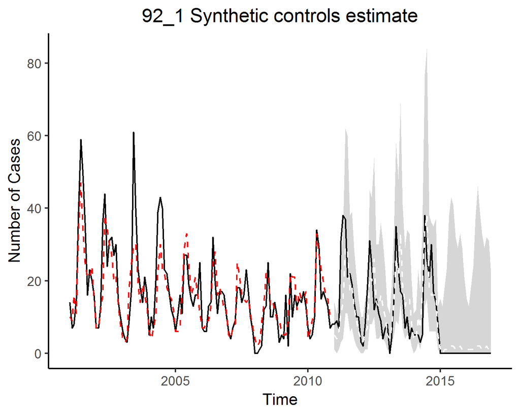

```r
      plots$groups[[1]]$pred_full
```

It is sometimes easier to look at the results if we aggregate the observed and expected values up to the annual time scale. Here the observed values are shown as black dots. When the black dots go below the gray shaded area, this indicates that the observed cases are lower than expected based on changes in the control diseases in the post-vaccine period. If the controls appropriately adjust for underlying trends, then this would reflect an effect of the vaccine. The vertical line indicates the date of vaccine introduction. The year when the vaccine is introduced is included to the right of the line, even if the vaccine was introduced part-way through the year. For instance, regardless of whether the the vaccine was introduced in January 2009 or November 2009, the observed dot for 2009 would be to the right of the line.

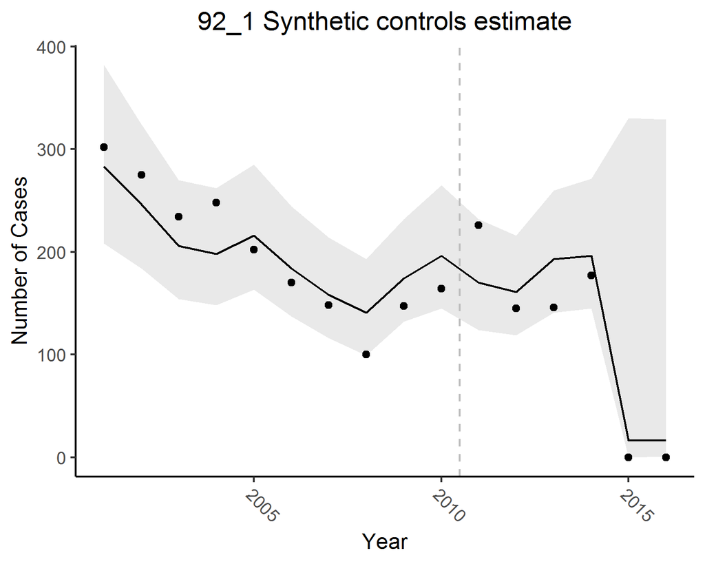

```r
      plots$groups[[1]]$pred_full_agg
```

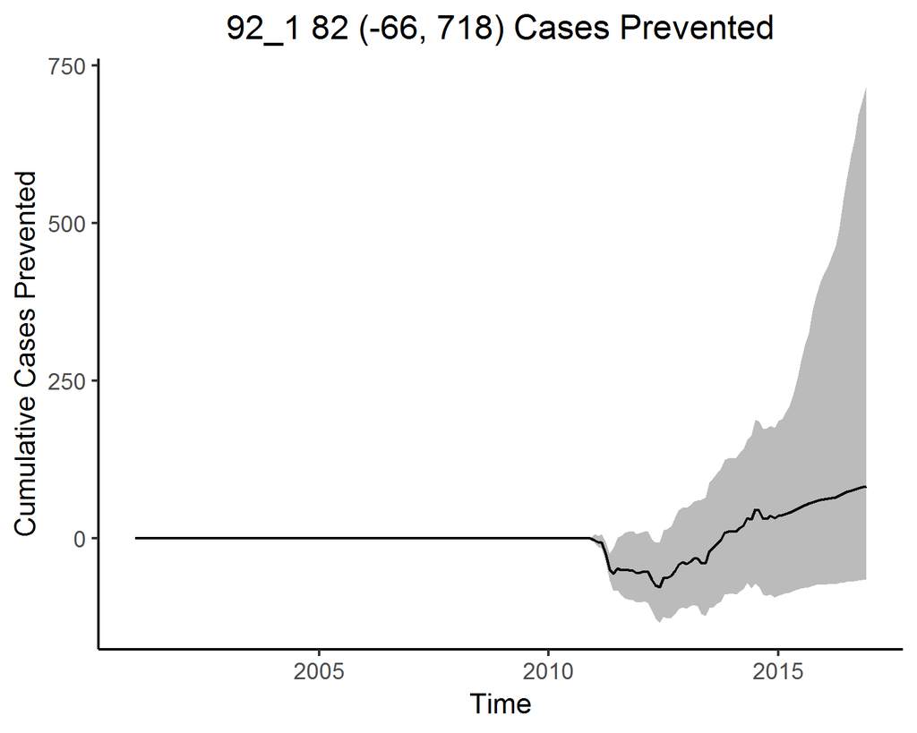

```r
      plots$groups[[1]]$cumsum_prevented
```

## Printing plots for all models and age groups

We instead might want to just print everything for all age groups and models. We can use the following code to do that

## Plot Observed vs expected yearly time series

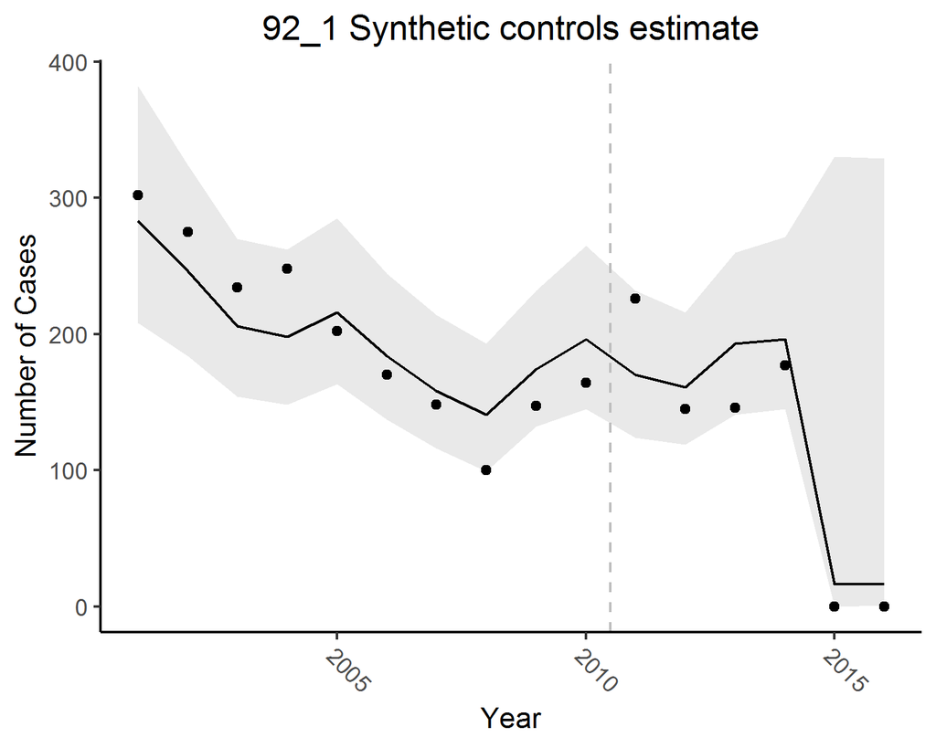

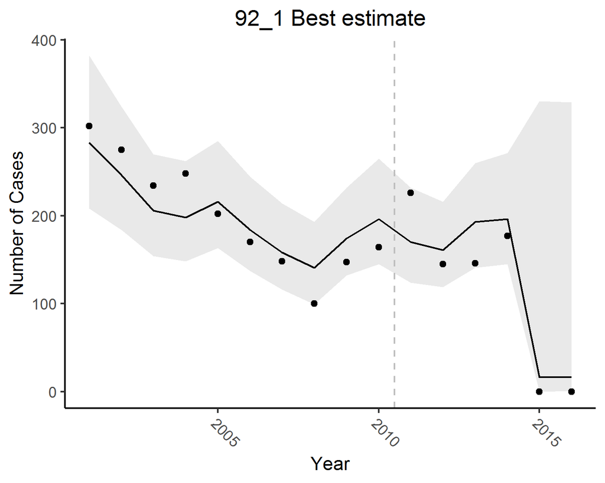

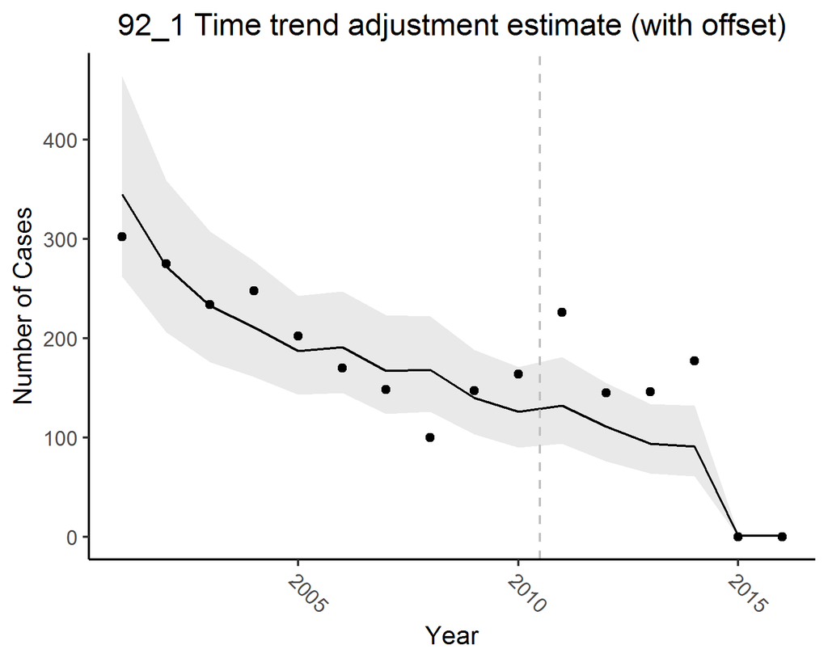

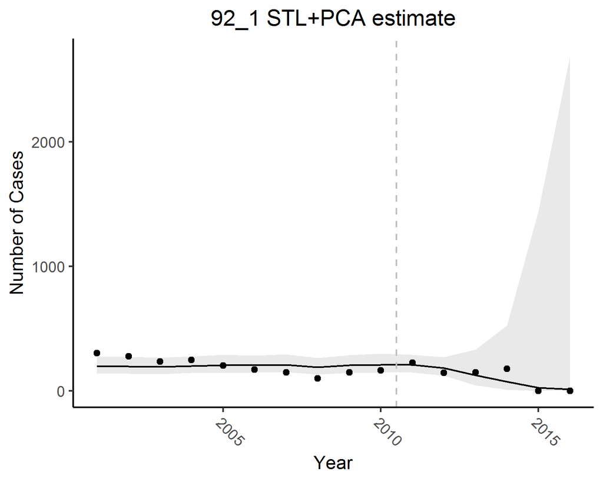

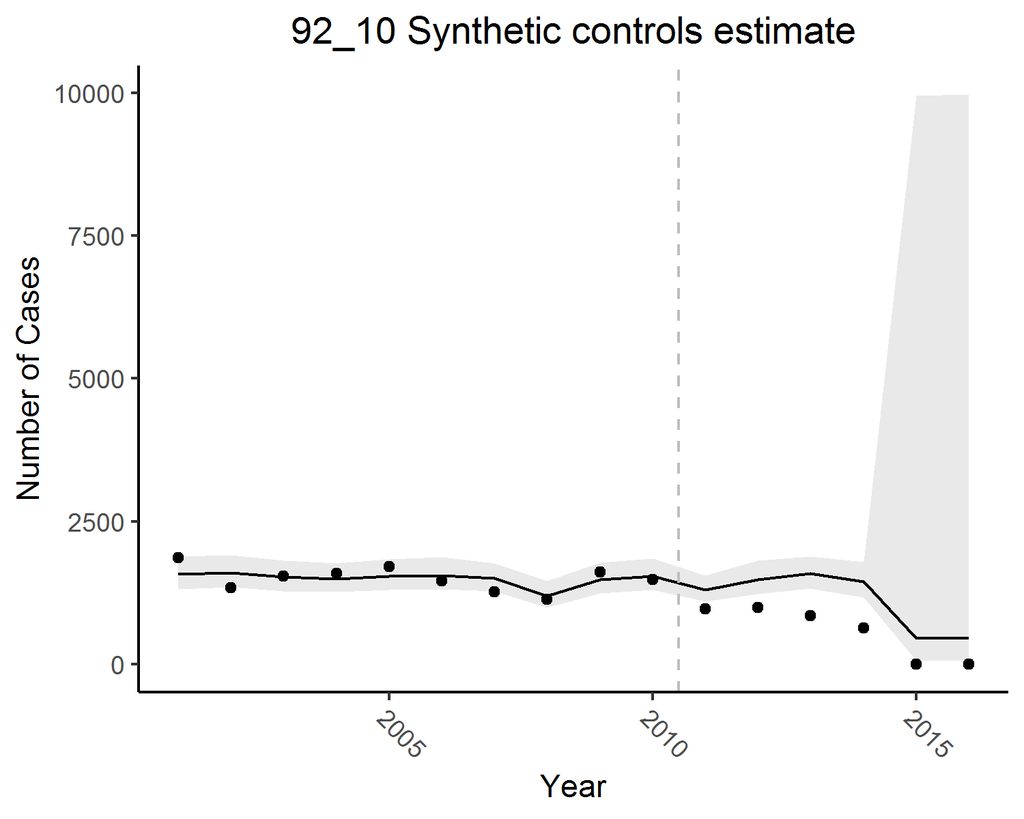

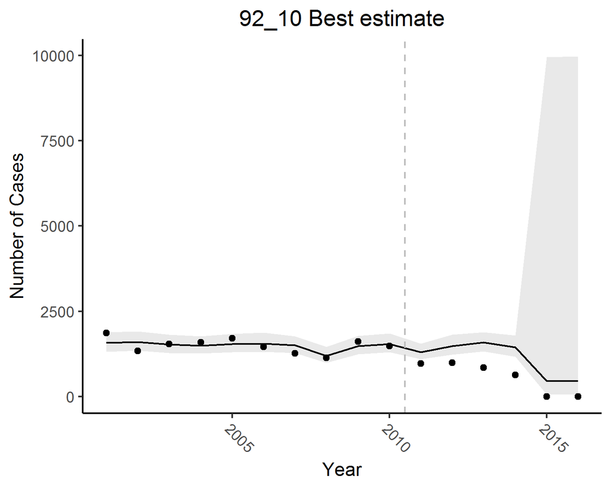

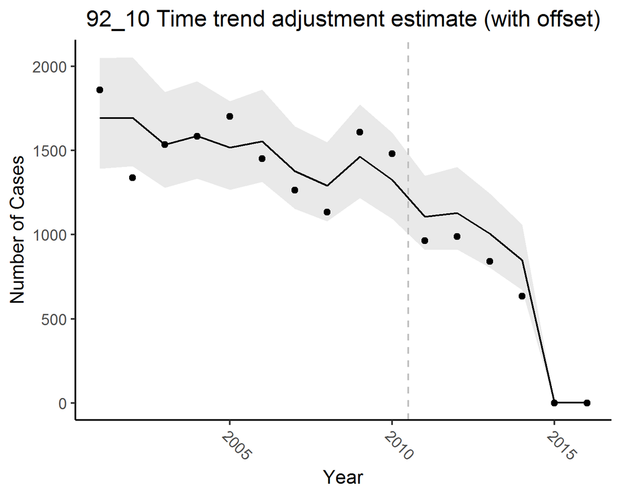

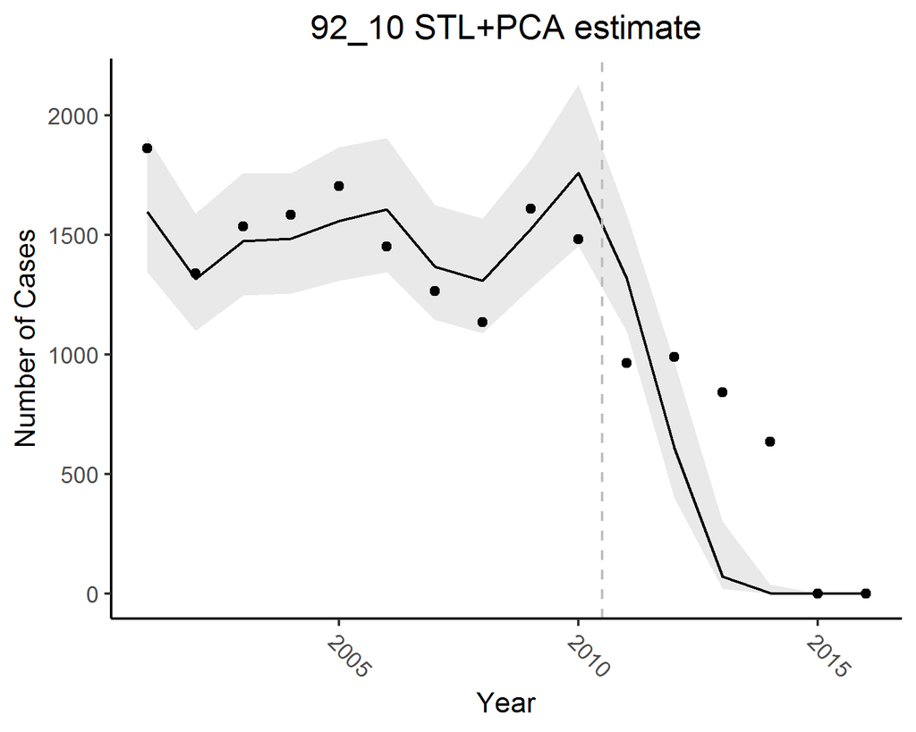

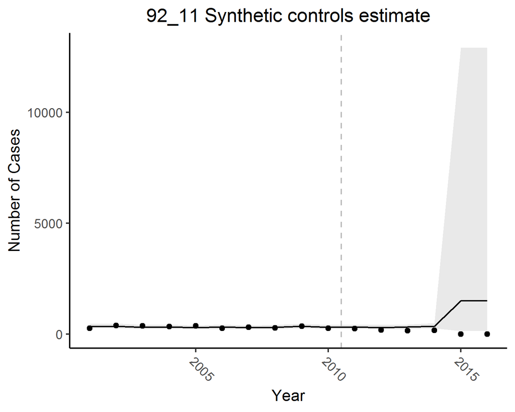

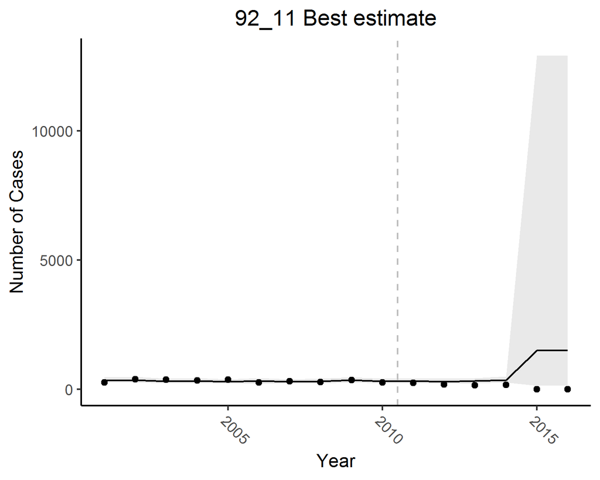

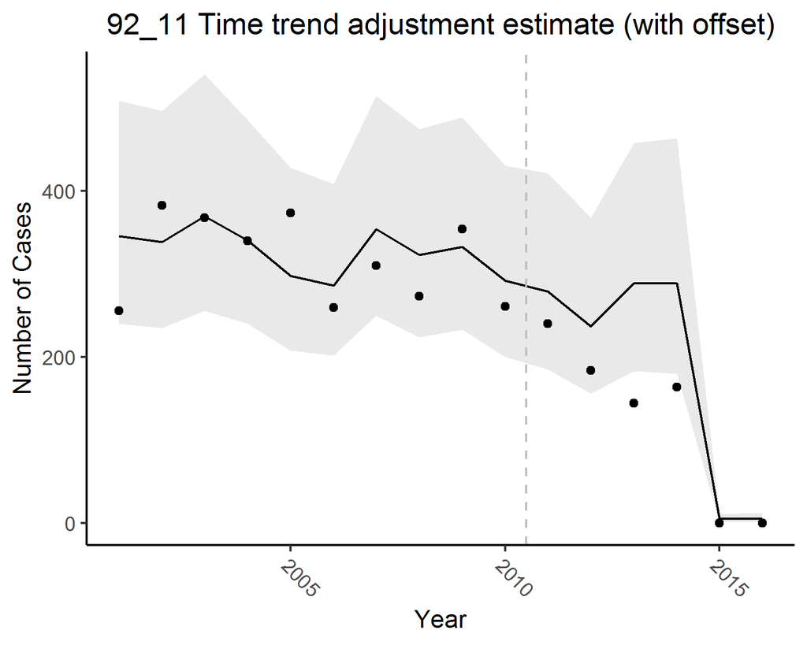

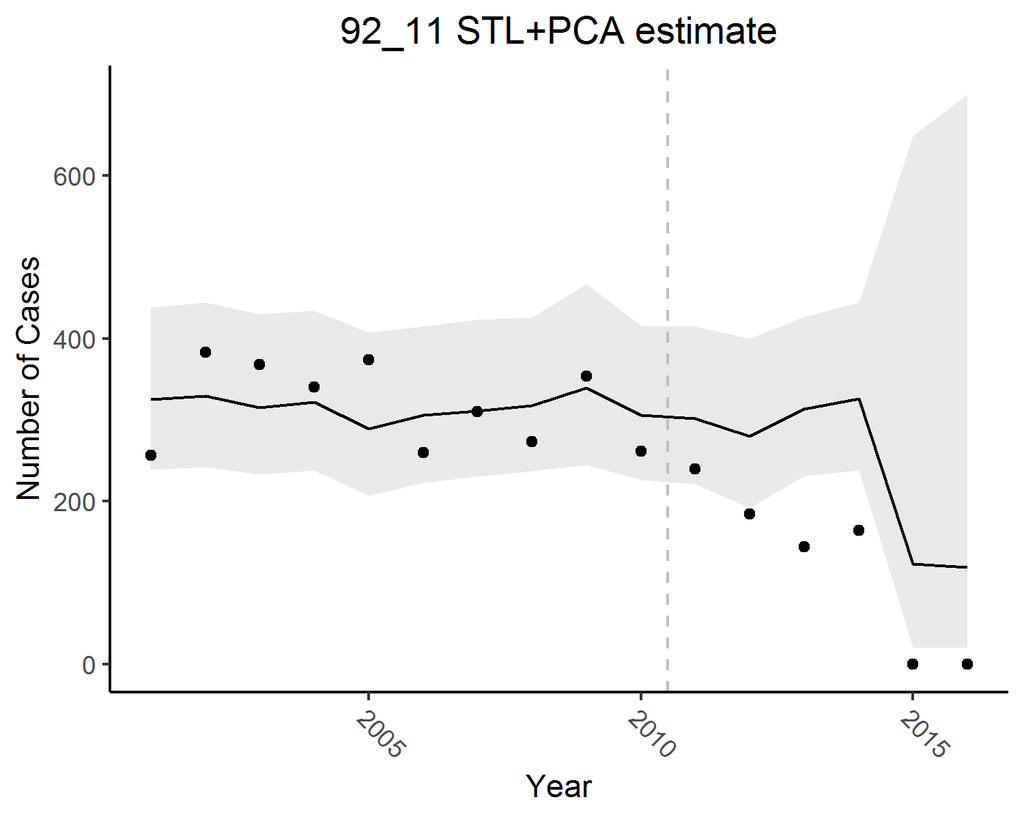

[48 more figures not shown]

```r
for (group in names(plots$groups)) {
      par(mfrow=c(4,1))
      print(plots$groups[[group]]$pred_full_agg )
      print(plots$groups[[group]]$pred_best_agg )
      print(plots$groups[[group]]$pred_time_agg )
      print(plots$groups[[group]]$pred_pca_agg )
}
```

## Use HDI intervals instead

The package calcuates both an equal-tail 95% credible interval and a 95% highest posterior density interval (HPD or HDI interval). The latter might be more appropriate when the posterior distribution is skewed. The objects with HDI intervals are saved with an appendix of ‘HDI’ so –impact_results$best$pred_quantiles gives the estimate for equal tail intervals while –impact_results$best$pred_quantiles_HDI gives the estimate for the HDI interval –impact_results$best$cumsum_prevented_hdi gives the estimate of cumulative cases prevented using HPI –impact_results$best$ann_pred_HDI gives the annual predicted cases with HDI intervals –impact_results$best$rr_mean_HDI gives the overall rate ratio caclulated with HDI intervals – impact_results$best$log_rr_hdi gives the pointswise log-RR with HDI intervals Here we compare the version calculated with equal-tailed intervals with HPD intervals. In this example they give very similar coverage

```r
print("Equal tailed intervals")
```

```
#> [1] "Equal tailed intervals"
```

```r
round(impact_results$best$rr_mean[,c(2,1,3)],2)
```

```
#>       Point Estimate Lower CI Upper CI
#> 92_1            0.78     0.38     0.98
#> 92_10           0.45     0.10     0.57
#> 92_11           0.12     0.02     0.41
#> 92_12           0.13     0.03     0.33
#> 92_13           0.02     0.00     0.45
#> 92_14           0.71     0.33     0.85
#> 92_15           0.64     0.36     0.87
#> 92_2            0.27     0.01     0.53
#> 92_3            0.59     0.09     0.96
#> 92_4            0.55     0.13     0.86
#> 92_5            0.64     0.42     0.73
#> 92_6            0.70     0.55     0.82
#> 92_7            0.56     0.26     0.72
#> 92_8            0.57     0.15     0.70
#> 92_9            0.27     0.02     0.60
```

```r
print("HPD intervals")
```

```
#> [1] "HPD intervals"
```

```r
round(impact_results$best$rr_mean_hdi,2)
```

```
#>       Point Estimate lower upper
#> 92_1            0.78  0.44  1.02
#> 92_10           0.45  0.14  0.59
#> 92_11           0.12  0.01  0.39
#> 92_12           0.13  0.01  0.29
#> 92_13           0.02  0.00  0.36
#> 92_14           0.71  0.39  0.87
#> 92_15           0.64  0.40  0.91
#> 92_2            0.27  0.00  0.50
#> 92_3            0.59  0.06  0.94
#> 92_4            0.55  0.15  0.87
#> 92_5            0.64  0.51  0.76
#> 92_6            0.70  0.57  0.83
#> 92_7            0.56  0.32  0.74
#> 92_8            0.57  0.18  0.72
#> 92_9            0.27  0.00  0.57
```

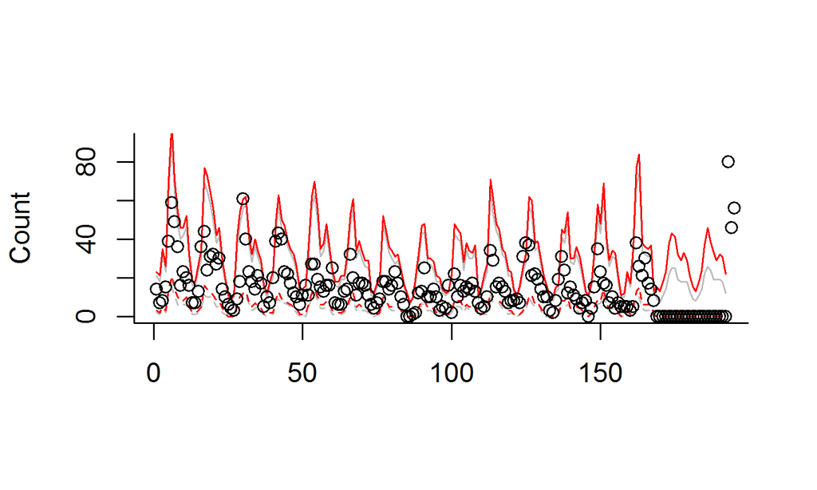

```r
matplot(impact_results$best$pred_quantiles_HDI[,c(2,3),1], type='l', col='gray', lty=c(2,1,2), bty='l', ylim=c(0, max(impact_results$best$pred_quantiles_HDI[,,1])), ylab='Count')

matplot(impact_results$best$pred_quantiles[,c(1,3),1], type='l', col='red', lty=c(2,1,2), bty='l', ylim=c(0, max(impact_results$best$pred_quantiles_HDI[,,1])), ylab='Count', add=T)
points(analysis$input_data[, analysis$outcome_name])
```